# Using the `countyfloods` package

Rod Lammers and Brooke Anderson

2017-10-25

## Basic example

You can use the `get_county_cd` function to get a vector of all counties within a state:

```r
get_county_cd(state = c("Georgia", "Alabama"))
```

```
##   [1] "01001" "01003" "01005" "01007" "01009" "01011" "01013" "01015"
##   [9] "01017" "01019" "01021" "01023" "01025" "01027" "01029" "01031"
##  [17] "01033" "01035" "01037" "01039" "01041" "01043" "01045" "01047"
##  [25] "01049" "01051" "01053" "01055" "01057" "01059" "01061" "01063"
##  [33] "01065" "01067" "01069" "01071" "01073" "01075" "01077" "01079"
##  [41] "01081" "01083" "01085" "01087" "01089" "01091" "01093" "01095"
##  [49] "01097" "01099" "01101" "01103" "01105" "01107" "01109" "01111"
##  [57] "01113" "01115" "01117" "01119" "01121" "01123" "01125" "01127"
##  [65] "01129" "01131" "01133" "13001" "13003" "13005" "13007" "13009"
##  [73] "13011" "13013" "13015" "13017" "13019" "13021" "13023" "13025"
##  [81] "13027" "13029" "13031" "13033" "13035" "13037" "13039" "13043"
##  [89] "13045" "13047" "13049" "13051" "13053" "13055" "13057" "13059"
##  [97] "13061" "13063" "13065" "13067" "13069" "13071" "13073" "13075"
## [105] "13077" "13079" "13081" "13083" "13085" "13087" "13089" "13091"
## [113] "13093" "13095" "13097" "13099" "13101" "13103" "13105" "13107"
## [121] "13109" "13111" "13113" "13115" "13117" "13119" "13121" "13123"
## [129] "13125" "13127" "13129" "13131" "13133" "13135" "13137" "13139"
## [137] "13141" "13143" "13145" "13147" "13149" "13151" "13153" "13155"
## [145] "13157" "13159" "13161" "13163" "13165" "13167" "13169" "13171"
## [153] "13173" "13175" "13177" "13179" "13181" "13183" "13185" "13187"
## [161] "13189" "13191" "13193" "13195" "13197" "13199" "13201" "13205"
## [169] "13207" "13209" "13211" "13213" "13215" "13217" "13219" "13221"
## [177] "13223" "13225" "13227" "13229" "13231" "13233" "13235" "13237"
## [185] "13239" "13241" "13243" "13245" "13247" "13249" "13251" "13253"
## [193] "13255" "13257" "13259" "13261" "13263" "13265" "13267" "13269"
## [201] "13271" "13273" "13275" "13277" "13279" "13281" "13283" "13285"
## [209] "13287" "13289" "13291" "13293" "13295" "13297" "13299" "13301"
## [217] "13303" "13305" "13307" "13309" "13311" "13313" "13315" "13317"
## [225] "13319" "13321"
```

You can use the `get_gages` function to pull all gages within a county or counties. For example, to get information on all gages for Miami-Dade county, you can run:

```r
library(dplyr)
get_gages("12086", start_date = "1988-01-01", end_date = "2015-01-01") %>%
  slice(1:5)
```

```
## # A tibble: 5 x 8
##   agency_cd         site_no
##       <chr>           <chr>
## 1      USGS       022908295
## 2      USGS 251203080480600
## 3      USGS 251154080471900
## 4      USGS 251033080440800
## 5      USGS        02289040
## # ... with 6 more variables: station_nm <chr>, site_tp_cd <chr>,
## #   dec_lat_va <dbl>, dec_long_va <dbl>, county_cd <chr>, DA <dbl>
```

You can use these two functions together within a pipe chain. For example, to get information on all the gages in Virginia in 2015, you can run:

```r
va_gages <- get_county_cd("Virginia") %>%
   get_gages(start_date = "2015-01-01", end_date = "2015-12-31")
head(va_gages)
```

```
##   agency_cd  site_no                                     station_nm
## 1      USGS 03207800                    LEVISA FORK AT BIG ROCK, VA
## 2      USGS 02013000                DUNLAP CREEK NEAR COVINGTON, VA
## 3      USGS 02014000                 POTTS CREEK NEAR COVINGTON, VA
## 4      USGS 02018500                 CATAWBA CREEK NEAR CATAWBA, VA
## 5      USGS 02011800 JACKSON RIVER BL GATHRIGHT DAM NR HOT SPGS, VA
## 6      USGS 02055100                TINKER CREEK NEAR DALEVILLE, VA
##   site_tp_cd dec_lat_va dec_long_va county_cd    DA
## 1         ST   37.35372   -82.19569     51027 297.0
## 2         ST   37.80290   -80.04700     51005 162.0
## 3         ST   37.72901   -80.04228     51005 153.0
## 4         ST   37.46819   -80.00532     51023  34.3
## 5         ST   37.94846   -79.94922     51005 345.0
## 6         ST   37.41763   -79.93532     51023  11.7
```

The function sends county-by-county requests to the USGS water services server (https://waterservices.usgs.gov) and, if there are data for gages within that county, returns that data and adds it to the dataframe returned by the function. This function may result in a message about a 404 HTTP status for some counties. This means that no data was found for one of the counties being queried but will not affect proper running of the function for other counties. Internally, this function uses the `whatNWISsites` function from the package, `dataRetrieval`, but adds the county FIPS code for each gage, allowing users to join gage data with other data identified by county FIPS. This function also uses the `readNWISsites` function from the `dataRetrieval` package to obtain the drainage area of the watershed at the selected gage. This can be used as a proxy for relative river size.

Once you have a list of gage numbers for which you would like to pull flow data, you can use the `get_flow_data` function to pull that data. For example, to pull data for all the stream gage flow data for 1999 for gages in Southhampton County, VA (FIPS code 51175), you can run:

```r
southampton_gages <- get_gages("51175", start_date = "1999-01-01",
                                end_date = "1999-12-31")
southampton_data <- get_flow_data(southampton_gages, start_date = "1999-01-01",
                                  end_date = "1999-12-31")
```

The output from `get_flow_data` is a data frame with daily streamflow for the queried gages over the requested dates. The data frame has three columns: “site_no” = gage number, “date” = date of observation, and “discharge” = mean daily flow in cubic feet per second (USGS parameter code 00060):

```r
head(southampton_data)
```

```
##    site_no       date discharge
## 1 02047000 1999-01-01       685
## 2 02047000 1999-01-02       631
## 3 02047000 1999-01-03       714
## 4 02047000 1999-01-04      1300
## 5 02047000 1999-01-05      2190
## 6 02047000 1999-01-06      2830
```

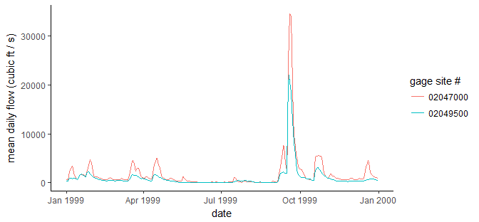

```r
library(ggplot2)
ggplot(southampton_data, aes(x = date, y = discharge, color = site_no)) +
  geom_line() + theme_classic() +
  labs(y = "mean daily flow (cubic ft / s)", color = "gage site #")
```

To determine when a flood occurred, we need a value to determine a gage-specific value of streamflow that consitutes a “flood”. Expected streamflow values vary substantially from gage to gage, so it is criticial to determine a sensible threshold for each gage included in a study before trying to identify floods at each gage.

One way to get gage-specific flood thresholds is with the `find_nws` function, which gets the National Weather Service flood discharge threshold, when available, for a gage site. Note there are four NWS thresholds for each gage, representing cutoffs for different levels of floods: “Action”, “Flood”, “Moderate”, and “Major”. These thresholds are available through the Advanced Hydrologic Prediction Service’s “River Stage” information. They are originally in feet for stages, which we convert to streamflow (in cubic feet per second) using USGS rating tables for each gage (pulled using the `readNWISrating` function from the `dataRetrieval` package).

Gages may have some, all, or none of these NWS flood thresholds available. If a gage does not have any of the four thresholds, it is excluded from the output of the `find_nws` function. For example, to get “Moderate” flood thresholds for the Virginia gages, you can run:

```r
va_nws <- find_nws(site_no = va_gages$site_no, type = "moderate")
head(va_nws)
```

```
##    site_no flood_val
## 1 01652500  8400.246
## 2 03168000 55378.500
## 3 02060500 28306.221
## 4 01654000  3370.084
## 5 03173000 17958.120
## 6 02011400  8008.627
```

```r
summary(va_nws$flood_val)
```

```
##    Min. 1st Qu.  Median    Mean 3rd Qu.    Max.
##    1719    8062   14039   22290   28306   90491
```

Many USGS gages do not have NWS flood thresholds for any of the four categories of floods. Therefore, use of the NWS flood thresholds to identify floods may severely limit the sample size of the data output.

Another way to get gage-specific flood thresholds is with the `find_q2` function, which calculates the median annual flood for each gage using a minimum of 20 years of USGS annual peak flow data:

```r
va_q2 <- find_q2(site_no = va_gages$site_no)
head(va_q2)
```

```
## # A tibble: 6 x 3
##    site_no flood_val years
##      <chr>     <dbl> <int>
## 1 01613900     923.0    56
## 2 01615000    2355.0    68
## 3 01620500     691.5    70
## 4 01621050     543.0    23
## 5 01622000    7440.0    87
## 6 01625000    5740.0    89
```

```r
summary(va_q2$flood_val)
```

```
##    Min. 1st Qu.  Median    Mean 3rd Qu.    Max.
##   113.5  2606.2  4970.0  9439.8  9476.7 70766.7
```

You can compare the results from these two methods for sites where you can get both values (note that both axes are shown on a log-10 scale):

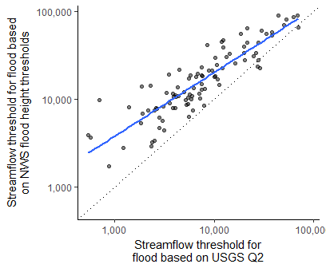

```r
va_flood_stage <- va_nws %>%
  rename(flood_nws = flood_val) %>%
  inner_join(va_q2, by = "site_no") %>%
  rename(flood_q2 = flood_val)
ggplot(va_flood_stage, aes(x = flood_q2, y = flood_nws)) +
  geom_point(alpha = 0.5) +
  geom_abline(aes(intercept = 0, slope = 1), linetype = 3) +
  geom_smooth(method = "lm", se = FALSE) +
  scale_x_log10(labels = scales::comma) + scale_y_log10(labels = scales::comma) +
  labs(x = "Streamflow threshold for\nflood based on USGS Q2",
       y = "Streamflow threshold for flood based\non NWS flood height thresholds") +
  theme_classic() +
  expand_limits(x = c(min(va_flood_stage$flood_q2, va_flood_stage$flood_nws),
                      max(va_flood_stage$flood_q2, va_flood_stage$flood_nws)),
                y = c(min(va_flood_stage$flood_q2, va_flood_stage$flood_nws),
                      max(va_flood_stage$flood_q2, va_flood_stage$flood_nws)))
```

For the Virginia monitors, you can see that the flood values from the “moderate” NWS flood heights and the Q2 method are well-correlated, although NWS values tend to be consistently higher than Q2 values.

Whichever flood threshold you pick, it can be joined to the time series streamflow data obtained with the `get_flow_data` function, and flood status can be determined on each day based on whether streamflow that day exceeded the threshold. For example, the following code can be used to add a binary `flood` variable to the streamflow data pulled earlier for Southampton County, VA:

```r
southampton_q2 <- find_q2(site_no = southampton_gages$site_no)
southampton_data <- southampton_data %>%
  left_join(southampton_q2, by = "site_no") %>%
  select(-years) %>%
  mutate(flood = discharge >= flood_val)
head(southampton_data)
```

```
##    site_no       date discharge flood_val flood
## 1 02047000 1999-01-01       685      7980 FALSE
## 2 02047000 1999-01-02       631      7980 FALSE
## 3 02047000 1999-01-03       714      7980 FALSE
## 4 02047000 1999-01-04      1300      7980 FALSE
## 5 02047000 1999-01-05      2190      7980 FALSE
## 6 02047000 1999-01-06      2830      7980 FALSE
```

Here are the time series for the two streamgages in the county, with horizontal lines added for the flood threshold used for each gage:

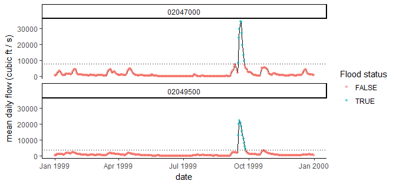

```r
library(ggplot2)
ggplot(southampton_data, aes(x = date, y = discharge)) +
  geom_line() + theme_classic() +
  geom_point(aes(color = flood), alpha = 0.5, size = 1.2) +
  facet_wrap(~ site_no, ncol = 1) +
  geom_hline(data = southampton_q2, aes(yintercept = flood_val),
             linetype = 3) +
  labs(y = "mean daily flow (cubic ft / s)", color = "Flood status")
```

Once you have data on gages, flood values, and flow data, you can also get flood summaries by site over the selected date range using the `flood_analysis` function. For each site, this function calculates the average “peak” (ratio of observed discharge to flood threshold discharge), maximum peak, and number of days where a flood occured. It also classifies flood magnitude. If the NWS flood threshold is used, this is a simple binary of “Flood” or “No Flood”. If the Q2 flood threshold is used, flood magnitude is classified based on “max_peak” value: “None” (<1), “Minor” (1-1.5), “Moderate” (1.5-2), “Major” (2-5), and “Extreme” (>5). For example, to get flood summary statistics by gage for the Virginia gages, you can run:

```r
va_counties <- get_county_cd("Virginia")
va_flow_data <- get_flow_data(va_gages, start_date = "2015-01-01",
                              end_date = "2015-12-31")
va_floods <- flood_analysis(flow_data = va_flow_data, peaks = va_q2,
                            gages = va_gages, county_cd = va_counties,
                            threshold = "Q2")
head(va_floods, 3)
```

```
## # A tibble: 3 x 14
##    site_no county_cd      lat      long   avg_peak flood_dur max_peak
##      <chr>     <chr>    <dbl>     <dbl>      <dbl>     <int>    <dbl>
## 1 02072000     51067 36.78069 -80.02476 0.26735068         8 3.953871
## 2 02040000     51007 37.42154 -77.85889 0.12193951         5 1.880193
## 3 03524500     51195 36.92927 -82.45626 0.06564179         2 1.876866
## # ... with 7 more variables: num_missing <int>, Q2 <lgl>, DA <dbl>,
## #   size <dbl>, state <fctr>, county <fctr>, flood <fctr>
```

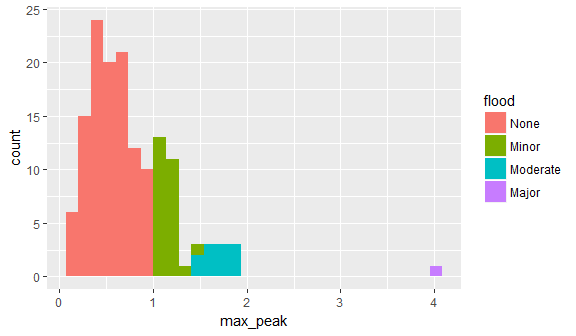

```r
ggplot(va_floods, aes(x = max_peak, fill = flood)) +
  geom_histogram()
```

There is also a function that will allow you to get county-level aggregate statistics from this gage-level summary. Any counties with no gages or for which the gages didn’t have flow data or flood threshold values are also included. If the Q2 flood threshold is used, this function gives the percentage of gages in the county above each flood magnitude classification (e.g. “Minor”, “Moderate”, etc.):

```r
va_county_stats <- county_aggregates(flood_stats = va_floods)
head(va_county_stats)
```

```
## # A tibble: 6 x 12
##   county_cd        county    state num_gage  avg_peak  max_peak minor
##       <chr>        <fctr>   <fctr>    <int>     <dbl>     <dbl> <dbl>
## 1     51001 accomack:main virginia        2       NaN      -Inf     0
## 2     51003     albemarle virginia        4 0.3655210 0.5557300     0
## 3     51005     alleghany virginia        4 0.7473739 0.8574018     0
## 4     51007        amelia virginia        2 1.5193316 1.8801932   100
## 5     51009       amherst virginia        1       NaN      -Inf     0
## 6     51011    appomattox virginia        1 0.3571429 0.3571429     0
## # ... with 5 more variables: moderate <dbl>, major <dbl>, extreme <dbl>,
## #   max_dur <dbl>, avg_dur <dbl>
```

You can use the `run_flood` function to put all of this together, and pull all flood summaries by either gage (`output = "gage"`), county (`output = "county"`), or both (`output = "both"`) for either a set of counties or all counties in a state. Because it is time consuming to pull flow data, it is more efficient to set (`output = "both"`) and then extract gage or county level data from the list rather than running each separately.

For example, to get all the flood statistics by gage for all gages with available data in Virginia, you can run:

```r
va_floods <- run_flood(state = "Virginia", start_date = "2015-01-01",
                       end_date = "2015-12-31", threshold = "Q2",
                       output = "gage")
head(va_floods)
```

```
## # A tibble: 6 x 14
##    site_no county_cd      lat      long   avg_peak flood_dur max_peak
##      <chr>     <chr>    <dbl>     <dbl>      <dbl>     <int>    <dbl>
## 1 02072000     51067 36.78069 -80.02476 0.26735068         8 3.953871
## 2 02040000     51007 37.42154 -77.85889 0.12193951         5 1.880193
## 3 03524500     51195 36.92927 -82.45626 0.06564179         2 1.876866
## 4 03527000     51169 36.64871 -82.75044 0.09350164         2 1.810000
## 5 02071530     51141 36.77847 -80.24922 0.06066979         1 1.788618
## 6 02069700     51141 36.57097 -80.12949 0.06708210         1 1.749420
## # ... with 7 more variables: num_missing <int>, Q2 <dbl>, DA <dbl>,
## #   size <dbl>, state <fctr>, county <fctr>, flood <fctr>
```

Similarly, to get county-level data for counties in Florida in 2004, you can run:

```r
fl_floods <- run_flood(state = "Florida", start_date = "2004-01-01",
                       end_date = "2004-12-31", threshold = "Q2",
                       output = "county")
head(fl_floods)
```

```
## # A tibble: 6 x 12
##   county_cd   county   state num_gage  avg_peak  max_peak minor moderate
##       <chr>   <fctr>  <fctr>    <int>     <dbl>     <dbl> <dbl>    <dbl>
## 1     12001  alachua florida        1 2.0661376 2.0661376 100.0      100
## 2     12003    baker florida        2 3.2362483 3.4654378 100.0      100
## 3     12005      bay florida        1 0.9708029 0.9708029   0.0        0
## 4     12007 bradford florida        1       NaN      -Inf   0.0        0
## 5     12009  brevard florida        8 2.4755538 4.7323944  87.5       75
## 6     12011  broward florida        1       NaN      -Inf   0.0        0
## # ... with 4 more variables: major <dbl>, extreme <dbl>, max_dur <dbl>,
## #   avg_dur <dbl>
```

These output can be mapped using the `map_flood` function. If the data was collected by gage, this will show a point map with the flood level at each gage. The size of the point corresponds to the size of the stream, based on either the median flood value (Q2) or the drainage area (DA). This defaults to Q2 but can be changed using the `weight` input to the `run_flood` function:

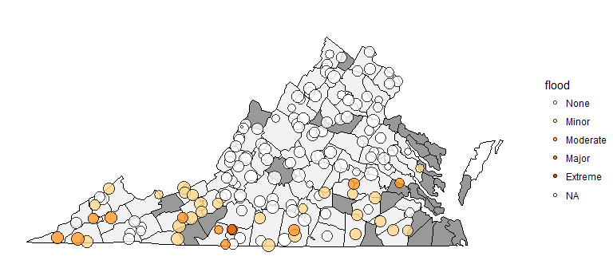

```r
map_flood(va_floods)
```

For county-level data, this will create a choropleth indicating the percent of gages in each county with flood magnitude above a user-specified flood category: “Low” (0-20%), “Moderate” (20-40%), “Moderate-High”" (40-60%), “High” (60-80%), and “Very High” (80-100%).

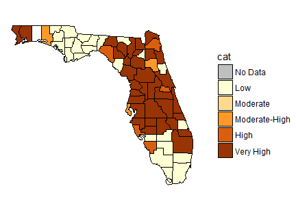

```r
map_flood(fl_floods)
```

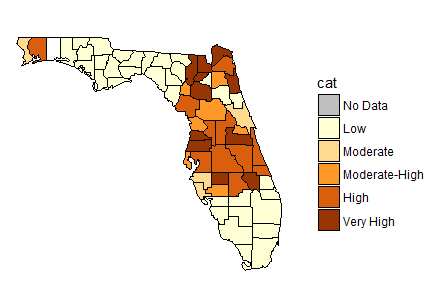

```r
map_flood(fl_floods, category = "major")
```

The `long_term_flood` function is very similar to the `run_flood` function except it accepts a data frame as input with three columns: `county_cd`, `start_date`, and `end_date`. This allows you to analyze floods across multiple date ranges and multiple counties. For example, if we wanted to examine April flooding in three counties in northern Virginia we would create the following input data frame:

```r
county_cd <- c(rep("51013", 5), rep("51107", 5), rep("51059", 5))
start_date <- rep(c("2010-04-01", "2011-04-01", "2012-04-01", "2013-04-01", "2014-04-01"), 3)
end_date <- rep(c("2010-04-30", "2011-04-30", "2012-04-30", "2013-04-30", "2014-04-30"), 3)
input_df <- data.frame(county_cd = county_cd, start_date = start_date, end_date = end_date, stringsAsFactors = FALSE)
head(input_df)
```

```
##   county_cd start_date   end_date
## 1     51013 2010-04-01 2010-04-30
## 2     51013 2011-04-01 2011-04-30
## 3     51013 2012-04-01 2012-04-30
## 4     51013 2013-04-01 2013-04-30
## 5     51013 2014-04-01 2014-04-30
## 6     51107 2010-04-01 2010-04-30
```

It is important that these variables are character strings and not factors. The flood analysis can then be performed:

```r
#With default values
va_floods <- long_term_flood(input_df)
va_gage_output <- va_floods[[1]]
head(va_gage_output)
```

```
##    site_no start_date   end_date county_cd      lat      long    avg_peak
## 1 01652500 2010-04-01 2010-04-30     51013 38.84333 -77.08586 0.005887097
## 2 01652500 2011-04-01 2011-04-30     51013 38.84333 -77.08586 0.006847634
## 3 01652500 2012-04-01 2012-04-30     51013 38.84333 -77.08586 0.004709785
## 4 01652500 2013-04-01 2013-04-30     51013 38.84333 -77.08586 0.004625376
## 5 01652500 2014-04-01 2014-04-30     51013 38.84333 -77.08586 0.020453548
## 6 01646000 2010-04-01 2010-04-30     51059 38.97594 -77.24581 0.031427007
##   flood_dur   max_peak num_missing       Q2   DA     size    state
## 1         0 0.02203226           0 3100.000 12.6 3.491362 virginia
## 2         0 0.04096774           0 3100.000 12.6 3.491362 virginia
## 3         0 0.06225806           0 3100.000 12.6 3.491362 virginia
## 4         0 0.02906452           0 3100.000 12.6 3.491362 virginia
## 5         0 0.23419355           0 3100.000 12.6 3.491362 virginia
## 6         0 0.07116788           0 1826.667 57.8 3.261659 virginia
##      county flood
## 1 arlington  None
## 2 arlington  None
## 3 arlington  None
## 4 arlington  None
## 5 arlington  None
## 6   fairfax  None
```

```r
va_county_output <- va_floods[[2]]
head(va_county_output)
```

```
## # A tibble: 6 x 14
##   county_cd start_date   end_date    county    state num_gage   max_peak
##       <chr>      <chr>      <chr>    <fctr>   <fctr>    <int>      <dbl>
## 1     51013 2010-04-01 2010-04-30 arlington virginia        1 0.02203226
## 2     51013 2011-04-01 2011-04-30 arlington virginia        1 0.04096774
## 3     51013 2012-04-01 2012-04-30 arlington virginia        1 0.06225806
## 4     51013 2013-04-01 2013-04-30 arlington virginia        1 0.02906452
## 5     51013 2014-04-01 2014-04-30 arlington virginia        1 0.23419355
## 6     51059 2010-04-01 2010-04-30   fairfax virginia        2 0.07116788
## # ... with 7 more variables: avg_peak <dbl>, minor <dbl>, moderate <dbl>,
## #   major <dbl>, extreme <dbl>, max_dur <dbl>, avg_dur <dbl>
```

If you are interested in seeing when flooding occurred over a set time period, you can perform a time series analysis using the `time_series_flood` function. This has similar inputs to the `run_flood` function. This will also output a `flood_metric` value which is the fraction of gages in the county experiencing a flood on that date, weighted by river size. River size is calculated as either the logarithm of the median annual flood (Q2, the default) or as the logarithm of the drainage area. This can be changed using the `weight` input. For example, if you wanted to examine when flooding occurred in Virginia from 2010 to 2015:

```r
va_time_series <- time_series_flood(state = "Virginia", start_date = "2010-01-01",
                      end_date = "2015-12-31", threshold = "NWS",
                      flood_type = "flood", weight = "Q2")
va_gage_output <- va_time_series[[1]]
head(va_gage_output)
```

```
##    site_no       date      lat      long county_cd       Q2    DA     size
## 1 02013000 2013-05-07 37.80290 -80.04700     51005 5516.667 162.0 3.741677
## 2 02018000 2013-07-04 37.66596 -79.91144     51023 7520.000 329.0 3.876218
## 3 02011500 2010-01-25 38.06957 -79.89700     51017 5510.000 134.0 3.741152
## 4 02011400 2010-01-25 38.04235 -79.88144     51017 3870.000 157.0 3.587711
## 5 02011470 2010-01-25 38.19040 -79.81172     51017 3112.500  75.6 3.493109
## 6 02011470 2011-04-28 38.19040 -79.81172     51017 3112.500  75.6 3.493109
##   discharge flood_val flood_ratio    state    county flood
## 1      8090  5906.626    1.369648 virginia alleghany Flood
## 2      8520  8059.431    1.057147 virginia botetourt Flood
## 3      5050  4613.418    1.094633 virginia      bath Flood
## 4      3470  3134.765    1.106941 virginia      bath Flood
## 5      3360  2556.761    1.314163 virginia      bath Flood
## 6      2630  2556.761    1.028645 virginia      bath Flood
```

```r
va_county_output <- va_time_series[[2]]
head(va_county_output)
```

```
## # A tibble: 6 x 10
##   county_cd       date  county    state num_gage max_peak  avg_peak
##       <chr>     <date>  <fctr>   <fctr>    <int>    <dbl>     <dbl>
## 1     51089 2010-01-25   henry virginia        2 1.073097 0.8541252
## 2     51105 2015-03-05     lee virginia        1 1.539506 1.5395064
## 3     51113 2010-01-25 madison virginia        2 1.914846 1.1225070
## 4     51113 2010-03-13 madison virginia        2 1.934091 1.0769796
## 5     51113 2011-04-17 madison virginia        2 1.295809 0.7585690
## 6     51113 2013-01-31 madison virginia        2 1.199585 0.7002309
## # ... with 3 more variables: no_flood <dbl>, yes_flood <dbl>,
## #   flood_metric <dbl>
```

The county-level output can be plotted using the `time_series_plot` function which shows bar charts of the timing and magnitude of floods during the selected time period. You can select values for `start_date` and `end_date` to change the x-limits on the plots or the default is to show the full time period including any flood. For example, here is the plot for Halifax County, VA:

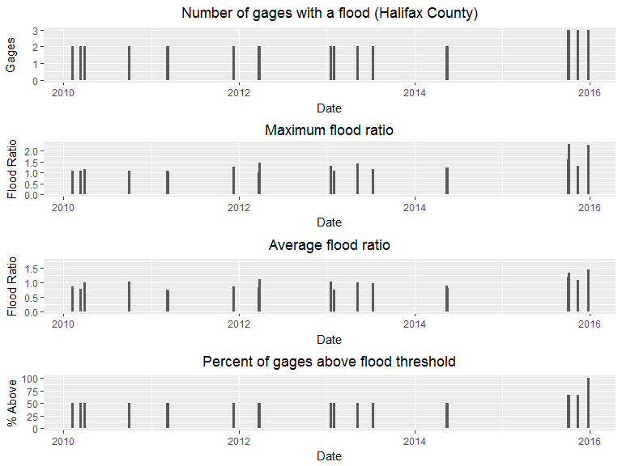

```r
time_series_plot(va_county_output[va_county_output$county == "halifax", ])
```

```r
  tx <- time_series_flood(state = "Texas", start_date = "2017-08-24", end_date = "2017-09-10", filter_data = FALSE)
  time_series_map(tx[[1]])
```

[output not shown]

The selection of Q2 or DA as a weight can affect results. These metrics are both meant to represent river size (larger rivers have a larger drainage area and median annual flood). Q2 is a more direct measurement of river size since it is based on the actual magnitude of river flows. Drainage area is a good proxy, however, when Q2 values are not available. The relationship between these two metrics can be compared for the `va_gage_output` data:

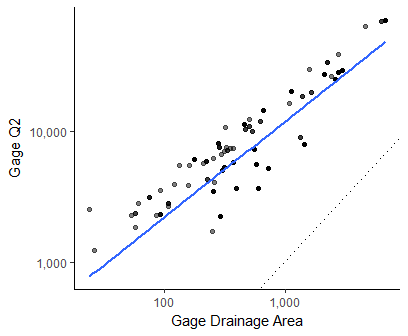

```r
ggplot(va_gage_output, aes(x = DA, y = Q2)) +
  geom_point(alpha = 0.5) +
  geom_abline(aes(intercept = 0, slope = 1), linetype = 3) +
  geom_smooth(method = "lm", se = FALSE) +
  scale_x_log10(labels = scales::comma) + scale_y_log10(labels = scales::comma) +
  labs(x = "Gage Drainage Area",
       y = "Gage Q2") +
  theme_classic() +
  expand_limits(x = c(min(va_gage_output$Q2, va_gage_output$DA),
                      max(va_gage_output$Q2, va_gage_output$DA)),
                y = c(min(va_gage_output$Q2, va_gage_output$DA),
                      max(va_gage_output$Q2, va_gage_output$DA)))
```

There is clearly a strong relationship between DA and Q2, although Q2 values (in this case) are far larger than DA. However, only one of these variables would be used at one time to compare relative river size so this will not affect the analysis.

The selection of the weight impacts the value of weighted `flood_metric`. We can compare the `flood_metric` values for the `va_county_output` using DA or Q2 as the weighting variable:

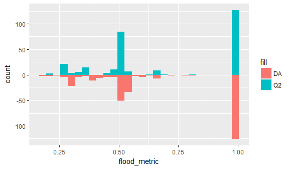

```r
va_county_output2 <- time_series_flood(state = "Virginia", start_date = "2010-01-01",
                      end_date = "2015-12-31", threshold = "NWS",
                      flood_type = "flood", weight = "DA")[[2]]

ggplot() +
  geom_histogram(data = va_county_output, aes(x = flood_metric, fill = "Q2"), binwidth = 0.03) +
  geom_histogram(data = va_county_output2, aes(x = flood_metric, y = - ..count.., fill = "DA"), binwidth = 0.03)
```

In this case, the results are not substantially different, althought the DA weights tend to give slightly higher `flood_metric` values. To get full, unfiltered results, set the `filter_data` input of `time_series_flood` to `FALSE`. Unweighted percentages of gages experiencing a flood on a given date are also returned (`yes_flood` column for NWS flood thresholds and by flood magnitude, e.g. `minor`, for Q2 flood thresholds).

## More detailed examples

Hurricane Floyd made landfall on Sept. 16, 1999, in North Carolina and caused extensive flooding, especially in the eastern part of the state. Here are maps for the month from Sept. 15, 1999 to Oct. 15, 1999:

```r
nc_floods <- run_flood(state = "North Carolina", start_date = "1999-09-15",
                       end_date = "1999-10-15", threshold = "Q2",
                       output = "both")
```

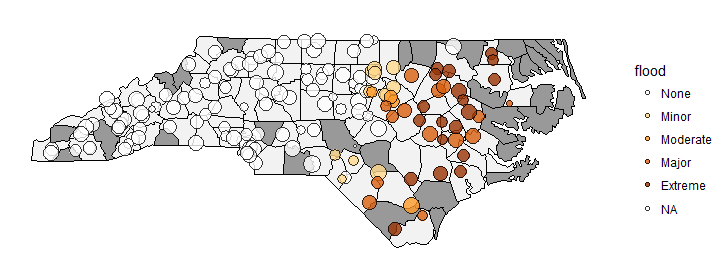

```r
nc_maps <- map_flood(nc_floods)
nc_maps[[1]]
```

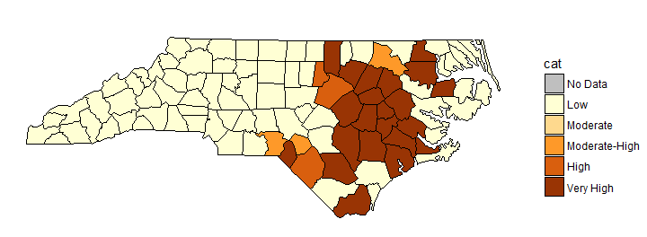

```r
nc_maps[[2]]
```

You can use the `map_tracks` function from `hurricaneexposure`, using the flood maps as the base `plot_object` in this call. For example:

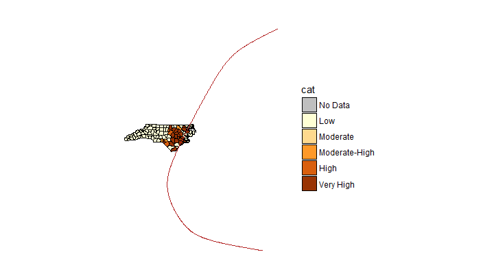

```r
library(hurricaneexposure)
map_tracks(storms = "Floyd-1999", plot_object = nc_maps[[2]])
```

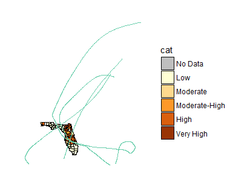

```r
map_tracks(storms = c("Bonnie-2004", "Charley-2004",
                      "Frances-2004", "Jeanne-2004"),
           plot_object = map_flood(fl_floods, category = "major"),
           color = "aquamarine3")
```